# Generating useful features for further analysis on Amazon reviews

## Introduction

**Business Context.** You are a business consultant with new clients that are interested in analyzing reviews of their products on Amazon (as opposed to Yelp). They want to answer business questions like: "What are the most important factors driving negative reviews?", "Have there been any large changes to customer satisfaction/reviews over time?", etc.

**Business Problem.** Your main task is to **explore the given data and use the results of your investigation to engineer relevant features that could facilitate subsequent analysis and model-building**.

**Analytical Context.** The dataset provided is a large body of reviews related to movies and television left on Amazon between 1996 and 2014. When exploring our dataset, we will quickly encounter a familiar problem we discussed in the previous case: the word "good" is one of the most important words in both positive *and* negative reviews. Thus, we must develop methods to put "good" in the appropriate context.

## Loading the data

We use a dataset of around 37,000 video reviews from Amazon Instant Video and 1,700,000 movie and TV reviews, all obtained from the website: http://jmcauley.ucsd.edu/data/amazon/. Note that there are much larger datasets available at the same site. We can expect better and more consistent results on larger datasets (such as book reviews). Note that these datasets are compressed (gzipped), and they are in JSON format, with each line representing a review and each line being its own JSON object.

We begin by loading the dataset below:

```python
%matplotlib inline
```

```python
%%time
import gzip
import json
import string
import re
import seaborn as sns
import matplotlib.pyplot as plt

import nltk # imports the natural language toolkit
import pandas as pd
import plotly

from collections import Counter
from datetime import datetime
from sklearn.feature_extraction.text import CountVectorizer

nltk.download('punkt')
```

```
CPU times: user 41.9 ms, sys: 12.1 ms, total: 53.9 ms
Wall time: 264 ms
```

```python
from google.colab import drive
drive.mount('/content/drive')
```

```python
%%time
# ----------
# we can tell pandas that our file is in gzip format and it will handle the decompression for us
# we also use `lines=True` to indicate that each line of the file is its own JSON object
instant_video = pd.read_json("drive/My Drive/Colab Notebooks/reviews_Amazon_Instant_Video_5.json.gz", lines=True, compression='gzip')
print(instant_video.head())
```

```
       reviewerID        asin  ... unixReviewTime   reviewTime
0  A11N155CW1UV02  B000H00VBQ  ...     1399075200   05 3, 2014
1  A3BC8O2KCL29V2  B000H00VBQ  ...     1346630400   09 3, 2012
2   A60D5HQFOTSOM  B000H00VBQ  ...     1381881600  10 16, 2013
3  A1RJPIGRSNX4PW  B000H00VBQ  ...     1383091200  10 30, 2013
4  A16XRPF40679KG  B000H00VBQ  ...     1234310400  02 11, 2009

[5 rows x 9 columns]
CPU times: user 1.78 s, sys: 105 ms, total: 1.88 s
Wall time: 1.91 s
```

```python
# ----------
# The Movies and TV file is very big. If you have problems loading it, you can load only the first
# 100,000 reviews by using 'chunksize' (uncomment the line with 'chunksize' and comment out the line
# after that which loads the entire file into `movies_tv`). All of the analysis can be
# done in the same way using only the subset of reviews but some of the results might be different from the examples.
# ----------

movies_tv = next(pd.read_json("drive/My Drive/Colab Notebooks/reviews_Movies_and_TV_5.json.gz", lines=True, compression='gzip', chunksize=100000))
print(movies_tv.head())
# I couldn't load the entire set due to the next error:
# EOFError: Compressed file ended before the end-of-stream marker was reached
# movies_tv = pd.read_json("reviews_Movies_and_TV_5.json.gz", lines=True, compression='gzip')
```

```
       reviewerID        asin  ... unixReviewTime   reviewTime
0   ADZPIG9QOCDG5  0005019281  ...     1203984000  02 26, 2008
1  A35947ZP82G7JH  0005019281  ...     1388361600  12 30, 2013
2  A3UORV8A9D5L2E  0005019281  ...     1388361600  12 30, 2013
3  A1VKW06X1O2X7V  0005019281  ...     1202860800  02 13, 2008
4  A3R27T4HADWFFJ  0005019281  ...     1387670400  12 22, 2013

[5 rows x 9 columns]
```

## Examining the data

We take a look at the first 5 rows of each dataset to see what attributes are available. These are

- **reviewerID:** A unique ID to identify the author of the review.
- **asin:** The ["Amazon Standard Identification Number"](https://www.amazon.com/gp/seller/asin-upc-isbn-info.html) which provides more information about the exact product and version.
- **reviewerName:** The username chosen by the reviewer.
- **helpful:** A record of how many users indicated that the review was helpful/not helpful.
- **reviewText:** The full text of the review.
- **overall:** The overall rating (1-5) left by the reviewer.
- **summary:** A short version of the review, used as the title.
- **unixReviewTime:** The date that the review was created, in [Unix Epoch](https://en.wikipedia.org/wiki/Unix_time) format.
- **reviewTime:** A human readable date giving the day, month, and year.

```python
movies_tv.info()
```

```
<class 'pandas.core.frame.DataFrame'>
RangeIndex: 100000 entries, 0 to 99999
Data columns (total 9 columns):
 #   Column          Non-Null Count   Dtype
---  ------          --------------   -----
 0   reviewerID      100000 non-null  object
 1   asin            100000 non-null  object
 2   reviewerName    99020 non-null   object
 3   helpful         100000 non-null  object
 4   reviewText      100000 non-null  object
 5   overall         100000 non-null  int64
 6   summary         100000 non-null  object
 7   unixReviewTime  100000 non-null  int64
 8   reviewTime      100000 non-null  object
dtypes: int64(2), object(7)
memory usage: 6.9+ MB
```

```python
print(len(instant_video))
print(instant_video.head(5))
```

```
37126
       reviewerID        asin  ... unixReviewTime   reviewTime
0  A11N155CW1UV02  B000H00VBQ  ...     1399075200   05 3, 2014
1  A3BC8O2KCL29V2  B000H00VBQ  ...     1346630400   09 3, 2012
2   A60D5HQFOTSOM  B000H00VBQ  ...     1381881600  10 16, 2013
3  A1RJPIGRSNX4PW  B000H00VBQ  ...     1383091200  10 30, 2013
4  A16XRPF40679KG  B000H00VBQ  ...     1234310400  02 11, 2009

[5 rows x 9 columns]
```

```python
print(len(movies_tv))
print(movies_tv.head(5))
```

```
100000
       reviewerID        asin  ... unixReviewTime   reviewTime
0   ADZPIG9QOCDG5  0005019281  ...     1203984000  02 26, 2008
1  A35947ZP82G7JH  0005019281  ...     1388361600  12 30, 2013
2  A3UORV8A9D5L2E  0005019281  ...     1388361600  12 30, 2013
3  A1VKW06X1O2X7V  0005019281  ...     1202860800  02 13, 2008
4  A3R27T4HADWFFJ  0005019281  ...     1387670400  12 22, 2013

[5 rows x 9 columns]
```

```python
%%time
movies_tv['datetime'] = pd.to_datetime(movies_tv['reviewTime'], format="%m %d, %Y")
instant_video['datetime'] = pd.to_datetime(instant_video['reviewTime'], format="%m %d, %Y")
```

```
CPU times: user 338 ms, sys: 41 µs, total: 338 ms
Wall time: 338 ms
```

```python
movies_tv = movies_tv.drop(columns = ['reviewerID', 'asin', 'reviewerName', 'reviewTime'])
instant_video = instant_video.drop(columns = ['reviewerID', 'asin', 'reviewerName', 'reviewTime'])

movies_tv.head(5)
```

|  | helpful | reviewText | overall | summary | unixReviewTime | datetime |
| --- | --- | --- | --- | --- | --- | --- |
| 0 | [0, 0] | This is a charming version of the classic Dick... | 4 | good version of a classic | 1203984000 | 2008-02-26 |
| 1 | [0, 0] | It was good but not as emotionally moving as t... | 3 | Good but not as moving | 1388361600 | 2013-12-30 |
| 2 | [0, 0] | Don't get me wrong, Winkler is a wonderful cha... | 3 | Winkler's Performance was ok at best! | 1388361600 | 2013-12-30 |
| 3 | [0, 0] | Henry Winkler is very good in this twist on th... | 5 | It's an enjoyable twist on the classic story | 1202860800 | 2008-02-13 |
| 4 | [0, 0] | This is one of the best Scrooge movies out. H... | 4 | Best Scrooge yet | 1387670400 | 2013-12-22 |

### Exercise 1:

#### 1.1

Plot histograms of all numeric quantities. Do you notice anything interesting about them?

**Answer.**

```python
#
movies_tv['helpful_yes'] = movies_tv['helpful'].apply(lambda x:re.sub(r"\[(\d+)\,\s(\d+)\]", r"\g<1>", str(x))).astype(int)
movies_tv['helpful_not'] = movies_tv['helpful'].apply(lambda x:re.sub(r"\[(\d+)\,\s(\d+)\]", r"\g<2>", str(x))).astype(int)
movies_tv['helpful_tot'] = movies_tv['helpful_yes'] + movies_tv['helpful_not']

instant_video['helpful_yes'] = instant_video['helpful'].apply(lambda x:re.sub(r"\[(\d+)\,\s(\d+)\]", r"\g<1>", str(x))).astype(int)
instant_video['helpful_not'] = instant_video['helpful'].apply(lambda x:re.sub(r"\[(\d+)\,\s(\d+)\]", r"\g<2>", str(x))).astype(int)
instant_video['helpful_tot'] = instant_video['helpful_yes'] + instant_video['helpful_not']
```

```python
intest_variables = ['overall', 'helpful_yes', 'helpful_not', 'helpful_tot']

def composedHistogram(data, varList):
  fig = plt.figure(figsize=(6,5))
  for i, var in enumerate(varList):
      plt.subplot(2,2,i+1)
      sns.distplot(data[var], kde=False)
      plt.title("Histogram of " + var)
  fig.set_tight_layout(True)
  plt.close()
  return fig
```

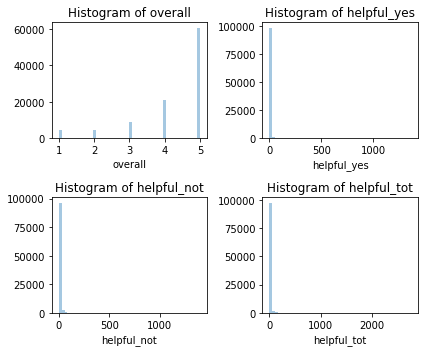

```python
composedHistogram(movies_tv, intest_variables)
```

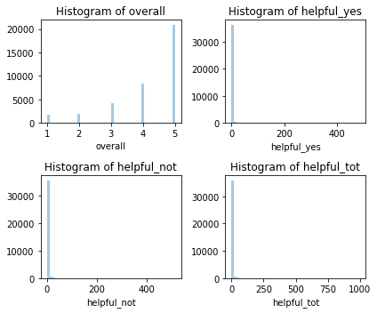

```python
composedHistogram(instant_video, intest_variables)
```

```python
#  instant_video.loc[:, intest_variables].describe()
#  movies_tv.loc[:, intest_variables].describe()
```

```python
# Calculate number of sentences and words
instant_video['sentences'] = instant_video['reviewText'].apply(lambda x: nltk.sent_tokenize(x))
instant_video['words'] = instant_video['reviewText'].apply(lambda x: nltk.word_tokenize(x))
```

```python
# Calculate number of sentences and words
movies_tv['sentences'] = movies_tv['reviewText'].apply(lambda x: nltk.sent_tokenize(x))
movies_tv['words'] = movies_tv['reviewText'].apply(lambda x: nltk.word_tokenize(x))
```

```python
def calculateLenghts(data):
  data['nChar'] = data['reviewText'].apply(lambda x: len(x))
  data['nWords'] = data['words'].apply(lambda x: len(x))
  data['nSent'] = data['sentences'].apply(lambda x: len(x))
calculateLenghts(instant_video)
calculateLenghts(movies_tv)
```

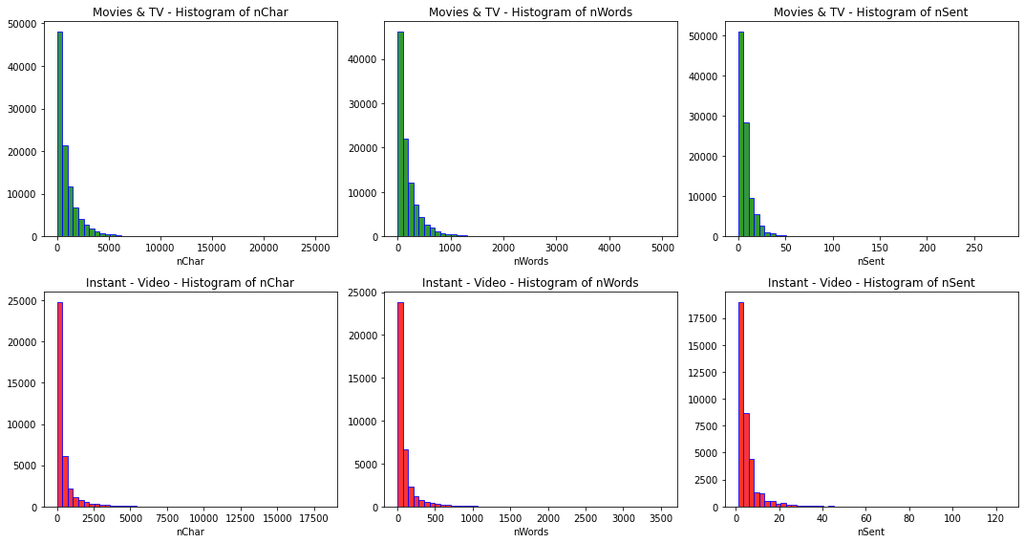

```python
other_variables = ['nChar', 'nWords', 'nSent']

fig = plt.figure(figsize=(15,8))
for i, var in enumerate(other_variables):
    plt.subplot(2,3,i+1)
    sns.distplot(movies_tv[var], kde=False, hist_kws={"linewidth": 1, "alpha": 0.8, "color": "g", "edgecolor":'b'})
    plt.title("Movies & TV - Histogram of " + var)
for i, var in enumerate(other_variables):
    plt.subplot(2,3,i+4)
    sns.distplot(instant_video[var], kde=False, hist_kws={"linewidth": 1, "alpha": 0.8, "color": "r", "edgecolor":'b'})
    plt.title("Instant - Video - Histogram of " + var)

fig.set_tight_layout(True)
```

For the dataset of Movies & TV the mean number of character, words and sentences for reviews are 949.16, 192.43, 7.94 respectively. This could be view as mean [and intercuartilic range] as 544 [213, 1242], 112 [45, 251], and 5 [3, 10] respectively.

For the dataset of Instant videos the mean number of character, words and sentences for reviews are 515.3, 106.1, 5.26 respectively. This could be view as mean [and intercuartilic range] as 232 [145, 484], 49 [31, 101], and 3 [2, 6] respectively.

These number indicates that the vast mayority of reviews aren't shallow and could describe the user preferences in a detailed way.

#### 1.2

How do average ratings change over time? Plot the average rating for each year and note any trends.

```python
movies_tv.sort_values('datetime', inplace=True)
instant_video.sort_values('datetime', inplace=True)
```

```python
def summaryTime(data, timePeriod):
  data1 = data\
  .set_index('datetime')\
  .to_period(timePeriod)\
  .groupby('datetime')\
  .mean()
  return data1
```

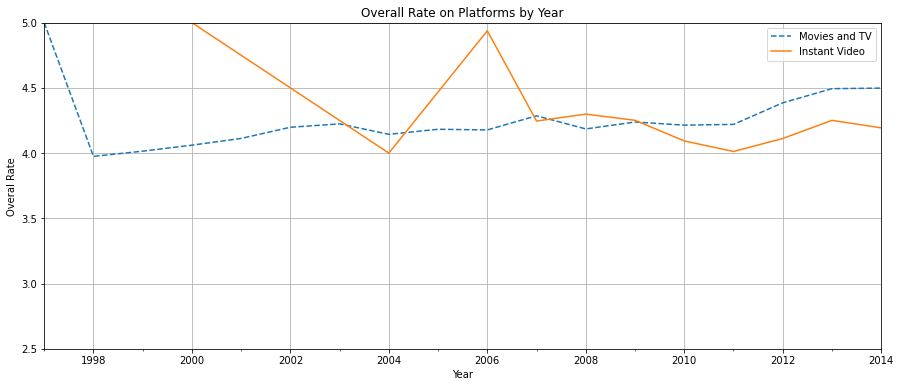

```python
fig, ax = plt.subplots(figsize=(15*1,3*2))

summaryTime(movies_tv, 'Y').plot(y = 'overall',  label='Movies and TV', ax=ax, linestyle="--")
summaryTime(instant_video, 'Y').plot(y = 'overall',  label='Instant Video', ax=ax, linestyle="-")
ax.set(ylim=(2.5,5), xlabel="Year", ylabel="Overal Rate", title='Overall Rate on Platforms by Year')
ax.grid(True)
```

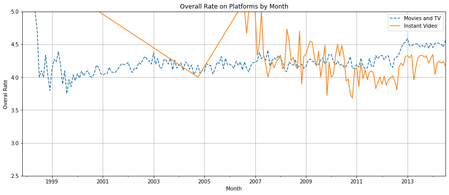

```python
fig, ax = plt.subplots(figsize=(15*1,3*2))

summaryTime(movies_tv, 'M').plot(y = 'overall',  label='Movies and TV', ax=ax, linestyle="--")
summaryTime(instant_video, 'M').plot(y = 'overall',  label='Instant Video', ax=ax, linestyle="-")
ax.set(ylim=(2.5,5), xlabel="Month", ylabel="Overal Rate", title='Overall Rate on Platforms by Month')
ax.grid(True)
```

A plot of time trends by month shows that there is greater variability in customer response for the instant video platform when compared to the film and TV platform. Therefore, the latter is a bit more predictable, and likewise an increase in favorability is observed since 2013 on both platforms, although the effect is more noticeable for the platform of Movies and TV.

#### 1.3

Look at the average length of the review by year. Do you notice any trends?

**Answer.**

```python
movies_TV_sum_Y = summaryTime(movies_tv, 'Y')
instant_video_sum_Y = summaryTime(instant_video, 'Y')
```

```
[Text(0.5, 1.0, 'No. Sentences by Year')]
```

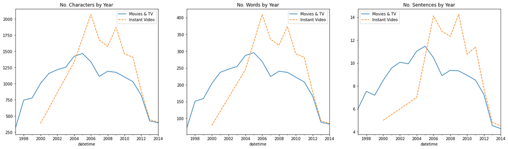

```python
fig, ax = plt.subplots(1, 3, figsize=(15*1.5,3*2))
movies_TV_sum_Y.plot(y = 'nChar',  label='Movies & TV', ax=ax[0], linestyle="-")
instant_video_sum_Y.plot(y = 'nChar',  label='Instant Video', ax=ax[0], linestyle="--")

movies_TV_sum_Y.plot(y = 'nWords',  label='Movies & TV', ax=ax[1], linestyle="-")
instant_video_sum_Y.plot(y = 'nWords',  label='Instant Video', ax=ax[1], linestyle="--")

movies_TV_sum_Y.plot(y = 'nSent',  label='Movies & TV', ax=ax[2], linestyle="-")
instant_video_sum_Y.plot(y = 'nSent',  label='Instant Video', ax=ax[2], linestyle="--")
ax[0].set(title = 'No. Characters by Year')
ax[1].set(title = 'No. Words by Year')
ax[2].set(title = 'No. Sentences by Year')
```

```python
movies_TV_sum_M = summaryTime(movies_tv, 'M')
instant_video_sum_M = summaryTime(instant_video, 'M')
```

```
[Text(0.5, 0, 'Year'), Text(0.5, 1.0, 'No. Sentences by Month')]
```

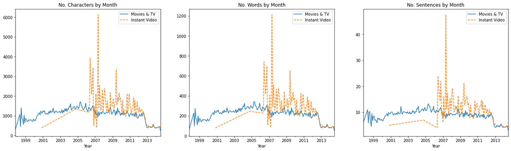

```python
fig, ax = plt.subplots(1, 3, figsize=(15*1.5,3*2))
movies_TV_sum_M.plot(y = 'nChar',  label='Movies & TV', ax=ax[0], linestyle="-")
instant_video_sum_M.plot(y = 'nChar',  label='Instant Video', ax=ax[0], linestyle="--")

movies_TV_sum_M.plot(y = 'nWords',  label='Movies & TV', ax=ax[1], linestyle="-")
instant_video_sum_M.plot(y = 'nWords',  label='Instant Video', ax=ax[1], linestyle="--")

movies_TV_sum_M.plot(y = 'nSent',  label='Movies & TV', ax=ax[2], linestyle="-")
instant_video_sum_M.plot(y = 'nSent',  label='Instant Video', ax=ax[2], linestyle="--")
ax[0].set(xlabel='Year', title = 'No. Characters by Month')
ax[1].set(xlabel='Year', title = 'No. Words by Month')
ax[2].set(xlabel='Year', title = 'No. Sentences by Month')
```

```python
movies_tv['year']  = movies_tv['datetime'].apply(lambda x: x.year)
movies_tv['month'] = movies_tv['datetime'].apply(lambda x: x.month)
instant_video['year']  = instant_video['datetime'].apply(lambda x: x.year)
instant_video['month'] = instant_video['datetime'].apply(lambda x: x.month)
```

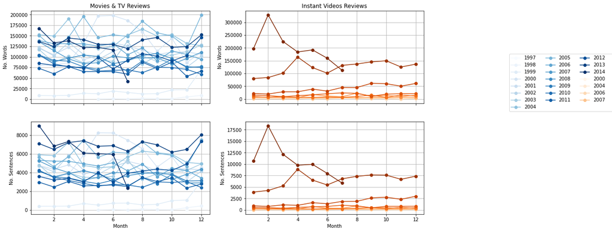

```python
def tableMonthYear(data, var):
  data1 = data\
  .groupby(['year', 'month'])[var]\
  .sum().reset_index()\
  .pivot(index='month', columns='year', values=var)
  return data1

fig, ax = plt.subplots(2,2, figsize=(15,8), sharey=False, sharex=True)

tableMonthYear(movies_tv, 'nWords').plot(marker = 'o', grid=True, cmap='Blues', ax = ax[0][0], legend=False)
tableMonthYear(movies_tv, 'nSent').plot(marker = 'o', grid=True, cmap='Blues', ax = ax[1][0], legend=False)
tableMonthYear(instant_video, 'nWords').plot(marker = 'o', grid=True, cmap='Oranges', ax = ax[0][1], legend=False)
tableMonthYear(instant_video, 'nSent').plot(marker = 'o', grid=True, cmap='Oranges', ax = ax[1][1], legend=False)
ax[0][0].set(xlabel='Month', ylabel='No. Words', title = 'Movies & TV Reviews')
ax[0][1].set(xlabel='Month', ylabel='No. Words', title = 'Instant Videos Reviews')
ax[1][0].set(xlabel='Month', ylabel='No. Sentences')
ax[1][1].set(xlabel='Month', ylabel='No. Sentences')

lines_labels = [ax.get_legend_handles_labels() for ax in [fig.axes[i] for i in [0,1]]]
lines, labels = [sum(lol, []) for lol in zip(*lines_labels)]
fig.legend(lines, labels, ncol=4, bbox_to_anchor=(1, 0.67), loc='upper left')
```

In a graph disaggregated by month and year, it is observed that there are a few months in which quite high reviews were elaborated for the Instant Video Platform compared to the Movies and TV Platform. In this composite graph, the decrease in the size of the reviews from 2013 is evident. This indicates that users have lost interest in expressing their comments on the quality of the service in recent years of the data sets.

### Exercise 2:

#### 2.1

Find the ten most frequently occuring non-stop words acrooss: (i) all reviews, (ii) positive reviews, (iii) negative reviews. Do the results surprise you? Why or why not?

**Answer.**  
For this case we define good reviews as such where Overall rating is equal or greater than 3, and bad reviews where ratings are below 3.

```python
nltk.download('stopwords')
from nltk.corpus import stopwords
# print(stopwords.words("english"))
```

```python
stop_words = set(stopwords.words("english"))    # Set stopwords from English
movies_tv['clean_words'] = movies_tv['words'].map(lambda x: [i for i in x if i.lower() not in stop_words])
instant_video['clean_words'] = instant_video['words'].map(lambda x: [i for i in x if i.lower() not in stop_words])
```

```python
# Unflatten by list comprenhension and removing only punctuation signs
mostCommonTotal_MT = Counter( [j for i in movies_tv['clean_words'] for j in i if not re.match(r'[^\w\d\s]', j) ])
mostCommonGood_MT = Counter( [j for i in movies_tv[movies_tv['overall'] >=3]['clean_words'] for j in i if not re.match(r'[^\w\d\s]', j) ])
mostCommonBad_MT = Counter( [j for i in movies_tv[movies_tv['overall'] < 3]['clean_words'] for j in i if not re.match(r'[^\w\d\s]', j) ])
```

```python
def custMultiIndex(t):
  return pd.MultiIndex.from_tuples([(t, 'Word'), (t, 'Count')])

pd.concat([
    pd.DataFrame(mostCommonTotal_MT.most_common(10), columns=custMultiIndex('All Reviews')),
    pd.DataFrame(mostCommonGood_MT.most_common(10), columns=custMultiIndex('Good Reviews')),
    pd.DataFrame(mostCommonBad_MT.most_common(10), columns=custMultiIndex('Bad Reviews'))],
    axis=1)
```

|  | All Reviews Word | All Reviews Count | Good Reviews Word | Good Reviews Count | Bad Reviews Word | Bad Reviews Count |
| --- | --- | --- | --- | --- | --- | --- |
| 0 | movie | 139071 | movie | 123755 | movie | 15316 |
| 1 | film | 112654 | film | 102335 | n't | 11389 |
| 2 | n't | 77134 | one | 66766 | film | 10319 |
| 3 | one | 73497 | n't | 65745 | one | 6731 |
| 4 | like | 46047 | like | 40021 | like | 6026 |
| 5 | quot | 44715 | quot | 39367 | quot | 5348 |
| 6 | good | 40405 | great | 38115 | would | 4362 |
| 7 | great | 40096 | good | 36483 | good | 3922 |
| 8 | time | 35733 | time | 32646 | even | 3466 |
| 9 | story | 33248 | story | 30445 | really | 3143 |

```python
# Unflatten by list comprenhension and removing only punctuation signs
mostCommonTotal_IV = Counter( [j for i in instant_video['clean_words'] for j in i if not re.match(r'[^\w\d\s]', j) ])
mostCommonGood_IV = Counter( [j for i in instant_video[instant_video['overall'] >=3]['clean_words'] for j in i if not re.match(r'[^\w\d\s]', j) ])
mostCommonBad_IV = Counter( [j for i in instant_video[instant_video['overall'] < 3]['clean_words'] for j in i if not re.match(r'[^\w\d\s]', j) ])
```

```python
pd.concat([
    pd.DataFrame(mostCommonTotal_IV.most_common(10), columns=custMultiIndex('All Reviews')),
    pd.DataFrame(mostCommonGood_IV.most_common(10), columns=custMultiIndex('Good Reviews')),
    pd.DataFrame(mostCommonBad_IV.most_common(10), columns=custMultiIndex('Bad Reviews'))],
    axis=1)
```

|  | All Reviews Word | All Reviews Count | Good Reviews Word | Good Reviews Count | Bad Reviews Word | Bad Reviews Count |
| --- | --- | --- | --- | --- | --- | --- |
| 0 | show | 24575 | show | 22409 | n't | 3459 |
| 1 | n't | 19633 | n't | 16174 | show | 2166 |
| 2 | like | 13950 | season | 12440 | like | 2017 |
| 3 | season | 13105 | like | 11933 | one | 1670 |
| 4 | one | 12966 | series | 11548 | movie | 1670 |
| 5 | series | 12254 | one | 11296 | 34 | 1412 |
| 6 | good | 11131 | good | 10065 | would | 1307 |
| 7 | 34 | 10178 | 34 | 8766 | film | 1154 |
| 8 | really | 8478 | great | 8016 | good | 1066 |
| 9 | watch | 8424 | watch | 7529 | really | 1066 |

There are no noticeable differences in the most frequent "no stop" words between good and bad reviews.

#### 2.2

Find words that are indicative of bad reviews. That is, words that appear often in bad reviews and *not* in good reviews. What are these words and are they surprising?

**Answer.**

```python
# Words that appear in bad reviews but not in good reviews
pd.concat([
  pd.DataFrame(
      # This line creates a dictionary (list) comprenhension first get keys from Counters in bad reviews that doesn't appear on mostCommonGood_IB
      # then creates a pair key-values and get them in a dictionary, the dictionary is converted in a counter again.
      # The most common function is applied in the counter.
      Counter({i:mostCommonBad_IV[i] for i in mostCommonBad_IV if i not in mostCommonGood_IV}).most_common(15),
      columns=custMultiIndex('Instant Videos')),
  pd.DataFrame(
      Counter({i:mostCommonBad_MT[i] for i in mostCommonBad_MT if i not in mostCommonGood_MT}).most_common(15),
      columns=custMultiIndex('Movies & TV'))
  ], axis=1)
```

|  | Instant Videos Word | Instant Videos Count | Movies & TV Word | Movies & TV Count |
| --- | --- | --- | --- | --- |
| 0 | niken | 20 | Rasheed | 22 |
| 1 | LiLo | 8 | MacLoud | 10 |
| 2 | AWFUL | 7 | MM2 | 10 |
| 3 | DAVE | 7 | five-way | 9 |
| 4 | BUSTERS | 7 | Yasha | 9 |
| 5 | Fella | 7 | L'Hotte | 8 |
| 6 | JAVA | 7 | MM3 | 8 |
| 7 | Mitchell-Hedges | 7 | 12/07Rate | 8 |
| 8 | Michod | 7 | Redlich | 8 |
| 9 | Achmed | 6 | D/D | 7 |
| 10 | Skyline | 6 | MM1 | 6 |
| 11 | Waste | 6 | F'in | 6 |
| 12 | Melt | 6 | Bugliosi | 6 |
| 13 | AREA_407 | 6 | MESCAL | 6 |
| 14 | SINGLE | 6 | 30AE | 6 |

The words that appear listed look like Common nouns so they could be refering to particular products. However, the frequency of appearance is low.

### Exercise 3:

Manually inspect the first 10 negative reviews containing the word "good". What do you notice? How does this suggest we ought to proceed next?

**Answer.**

```python
[print(i) for i in (movies_tv[(movies_tv['overall'] <3) &
                              (movies_tv['clean_words'].map(lambda x: 'good' in x))]
                    .head(10)['reviewText']
                    .map(lambda x: x[x.find(r'good')-30:x.find(r'good')+60]))]
```

```
hen up close where there is a good chance that you will  also blow up your own troops.I'm
were ruining something really good.
it's Spielberg, so it must be good, right?
ir restaurant. The food looks good, and there are one or two  moments  that would have bee
enough. Why a movie with such good actors can be that bad ; that's the question to ask! Fi
e super glue and she'll be as good as  new.&quot; Just give it up all ready, PLEASE!!!!!!!
tart. The special effects ARE good and therein lies the problem. Typical of today's films,
dy  occasionally but I need a good meal sooner or later.
e plot, although  potentially good, failed to deliver. I saw the movie twice just to find
ve 'atmosphere' and mood with good lighting effects; and restrained, unmelodramatic acting
```

```
[None, None, None, None, None, None, None, None, None, None]
```

```python
[print(i) for i in (instant_video[(instant_video['overall'] <3) &
                                  (instant_video['clean_words'].map(lambda x: 'good' in x))]
                    .head(10)['reviewText']
                    .map(lambda x: x[x.find(r'good')-30:x.find(r'good')+60]))]
```

```
ck a little. Everyone loves a good mystery!Dani Reese's (the woman agent) emotional respon
sing his vampire skills to do good as a private detective (it is implied, though not direc
s I usually trust found to be good. Guess that's not the best way either! Oh well, I found
e capable of actually writing good stories, intelligent characters and compelling stories
as it is, there's still a few good things buried under the cheese. It's kind of like an en
s Wife (Jennifer Siebold)both good actors, play very unlikable characters. In fact only Ad
is probably the best and only good thing in this show.
ly Robert Englund is having a good time, and watching him as the sleazy (and cowardly) own
that the show was really very good. Until, at first Earls goes to prison, during which tim
e Randy Marsh character. He's good for a part in an episode, but it's been proven in the p
```

```
[None, None, None, None, None, None, None, None, None, None]
```

### Exercise 4:

Go through the list of bad reviews containing the word "good" that we found in the last question. For each review, extract the following:

1. The first word after "good"
2. The first word after "good" that is a noun or cardinal
3. The last word before "good" that is a noun or cardinal

**Answer.**

```python
nltk.download('averaged_perceptron_tagger')
```

```
True
```

```python
def searchGoodMoreOneByIndex(x):
  keyList = [i[0] for i in x]
  try:
    positionGood = keyList.index('good')        # Position of word 'Good'
    x1 = x[positionGood + 1]                    # Returns a Word
  except:
    x1 = 'None'
  return x1

def selectFirstWordAfterGood(data):
  result = (
    data[(data['overall'] <3) &
         (data['clean_words'].map(lambda x: 'good' in x))]
  .head(10)['clean_words']
  .map(lambda x: nltk.pos_tag(x))
  .map(lambda x: [i for i in x if not re.match(r'[^\w\d\s]', i[1])]) # Remove words that are punctuation signs
  .map(lambda x: searchGoodMoreOneByIndex(x))                        # Some sentences ends with good, so there is not a word after good
 )
  return result

multiCol4 = pd.MultiIndex.from_tuples([('Instant Video', 'Index'), ('Instant Video', 'Clean Word'),
                                          ('Movies & TV', 'Index'), ('Movies & TV', 'Clean Word')])

DF41 = pd.concat([
  selectFirstWordAfterGood(instant_video).reset_index(),
  selectFirstWordAfterGood(movies_tv).reset_index()],
  axis = 1
)
DF41.columns = multiCol4
DF41
```

|  | Instant Video Index | Instant Video Clean Word | Movies & TV Index | Movies & TV Clean Word |
| --- | --- | --- | --- | --- |
| 0 | 1383 | (mystery, NN) | 6708 | (chance, NN) |
| 1 | 1736 | (private, JJ) | 41332 | None |
| 2 | 943 | (Guess, NNP) | 50320 | (right, RB) |
| 3 | 1429 | (stories, NNS) | 5996 | (one, CD) |
| 4 | 2045 | (things, NNS) | 12698 | (actors, NNS) |
| 5 | 1367 | (actors, NNS) | 41135 | (new., NN) |
| 6 | 2149 | (thing, NN) | 6934 | (therein, NN) |
| 7 | 2060 | (time, NN) | 14813 | (meal, NN) |
| 8 | 1776 | (first, JJ) | 36302 | (failed, VBD) |
| 9 | 3237 | (part, NN) | 79831 | (lighting, NN) |

```python
def searchFirstNounAfterGoodByIndex(x):
  keyList = [i[0] for i in x]
  try:
    positionGood = keyList.index('good')                                # Position of word 'Good'
    x1 = x[(positionGood + 1):]                                         # Select all words after good as determined by index
    x1 = [i for i in x1 if i[1] in ['NN', 'NNS', 'NNP', 'NNPS', 'CD']]  # Filter nouns (NN singular, NNS plural, NNP proper singular, NNPS proper plural) and cardinals (CD)
    x1 = x1[0]                                                          # Select the First word after 'good'
  except:
    x1 = 'None'
  return x1

def selectFirstNounAfterGoodByIndex(data):
  result = (
    data[(data['overall'] <3) &
         (data['clean_words'].map(lambda x: 'good' in x))]
  .head(10)['clean_words']
  .map(lambda x: nltk.pos_tag(x))
  .map(lambda x: [i for i in x if not re.match(r'[^\w\d\s]', i[1])])        # Remove words that are punctuation signs
  .map(lambda x: searchFirstNounAfterGoodByIndex(x))                        # Some sentences ends with good, so there is not a word after good
 )
  return result

DF42 = pd.concat([
  selectFirstNounAfterGoodByIndex(instant_video).reset_index(),
  selectFirstNounAfterGoodByIndex(movies_tv).reset_index()],
  axis = 1
)
DF42.columns = multiCol4
DF42
```

|  | Instant Video Index | Instant Video Clean Word | Movies & TV Index | Movies & TV Clean Word |
| --- | --- | --- | --- | --- |
| 0 | 1383 | (mystery, NN) | 6708 | (chance, NN) |
| 1 | 1736 | (detective, NN) | 41332 | None |
| 2 | 943 | (Guess, NNP) | 50320 | None |
| 3 | 1429 | (stories, NNS) | 5996 | (one, CD) |
| 4 | 2045 | (things, NNS) | 12698 | (actors, NNS) |
| 5 | 1367 | (actors, NNS) | 41135 | (new., NN) |
| 6 | 2149 | (thing, NN) | 6934 | (therein, NN) |
| 7 | 2060 | (time, NN) | 14813 | (meal, NN) |
| 8 | 1776 | (Earls, NNP) | 36302 | (deliver, NN) |
| 9 | 3237 | (part, NN) | 79831 | (lighting, NN) |

```python
def searchLastNounBeforeGoodByIndex(x):
  keyList = [i[0] for i in x]
  try:
    positionGood = keyList.index('good')                                # Position of word 'Good'
    x1 = x[:(positionGood + 1)]                                         # Select all words after good as determined by index
    x1 = [i for i in x1 if i[1] in ['NN', 'NNS', 'NNP', 'NNPS', 'CD']]  # Filter nouns (NN singular, NNS plural, NNP proper singular, NNPS proper plural) and cardinals (CD)
    x1 = x1[-1]                                                          # Select the First word after 'good'
  except:
    x1 = 'None'
  return x1

def selectLastNounBeforeGoodByIndex(data):
  result = (
      data[(data['overall'] <3) &
           (data['clean_words'].map(lambda x: 'good' in x))]
            .head(10)['clean_words']
            .map(lambda x: nltk.pos_tag(x))
            .map(lambda x: [i for i in x if not re.match(r'[^\w\d\s]', i[1])])   # Remove words that are punctuation signs
            .map(lambda x: searchLastNounBeforeGoodByIndex(x))
  )
  return result

DF43 = pd.concat([
  selectLastNounBeforeGoodByIndex(instant_video).reset_index(),
  selectLastNounBeforeGoodByIndex(movies_tv).reset_index()],
  axis = 1
)
DF43.columns = multiCol4
DF43
```

|  | Instant Video Index | Instant Video Clean Word | Movies & TV Index | Movies & TV Clean Word |
| --- | --- | --- | --- | --- |
| 0 | 1383 | (Everyone, NN) | 6708 | (missiles, NNS) |
| 1 | 1736 | (skills, NNS) | 41332 | (something, NN) |
| 2 | 943 | (reviewers, NNS) | 50320 | (Spielberg, NNP) |
| 3 | 1429 | (people, NNS) | 5996 | (food, NN) |
| 4 | 2045 | (cheese, NN) | 12698 | (movie, NN) |
| 5 | 1367 | (Siebold, NNP) | 41135 | (glue, NN) |
| 6 | 2149 | (Williams, NNP) | 6934 | (effects, NNS) |
| 7 | 2060 | (Englund, NNP) | 14813 | (candy, NN) |
| 8 | 1776 | (show, NN) | 36302 | (plot, NN) |
| 9 | 3237 | (character, NN) | 79831 | (mood, NN) |

The words found are not really informative, we can't tell what are they referring.

### Exercise 5:

We have seen that individual words are not always very informative. Look for the most informative bigrams and trigrams, in both positive and negative reviews. Show the most informative bigrams and trigrams and give a brief analysis of the n-grams you identified.

**Answer.**

```python
from nltk.util import ngrams
```

```python
def columnwithNgrams(data, n, k):
  dummy = data.map(lambda x: [i for i in x if not re.match(r'[^\w\d\s]', i)])
  dummy = dummy.map(lambda x: [' '.join(i) for i in (ngrams(x, n))])
  most_common_k = Counter([i for j in dummy for i in j]).most_common(k)
  return most_common_k
# dummy =columnwithNgrams(movies_tv['clean_words'], 2, 10)
```

```python
def summaryPlotGram(data, n, k, color, ax):
  du = columnwithNgrams(data, n, k)
  df = pd.DataFrame({'Gram': dict(du).keys(), 'Count':map(int, dict(du).values())})
  df = df.sort_values('Count')
  plot = df.plot.barh(x='Gram', y='Count', color=color, ax=ax)
  return plot

# summaryPlotGram(movies_tv['clean_words'], 2, 10, 'blue')
```

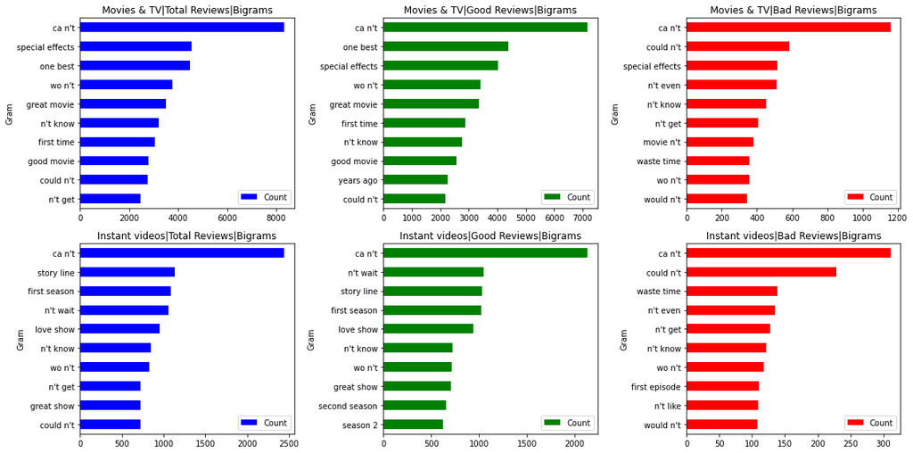

```python
%matplotlib inline
fig, ax = plt.subplots(2,3, figsize=(16,8))
summaryPlotGram(movies_tv['clean_words'], 2, 10, 'blue', ax[0][0])                                      # Total reviews, 10 frec bigrams (Movies&TV) -
summaryPlotGram(instant_video['clean_words'], 2, 10, 'blue', ax[1][0])                                  # Total reviews, 10 frec bigrams (Instant video) -
summaryPlotGram(movies_tv[movies_tv['overall'] >=3]['clean_words'], 2, 10, 'green', ax[0][1])           # Good reviews, 10 frec bigrams (Movies&TV) -
summaryPlotGram(instant_video[instant_video['overall'] >=3]['clean_words'], 2, 10, 'green', ax[1][1])   # Good reviews, 10 frec bigrams (Instant video) -
summaryPlotGram(movies_tv[movies_tv['overall'] <3]['clean_words'], 2, 10, 'red', ax[0][2])              # Bad reviews, 10 frec bigrams (Movies&TV) -
summaryPlotGram(instant_video[instant_video['overall'] <3]['clean_words'], 2, 10, 'red', ax[1][2])      # Bad reviews, 10 frec bigrams (Instant video) -
ax[0][0].set(title = 'Movies & TV|Total Reviews|Bigrams')
ax[1][0].set(title = 'Instant videos|Total Reviews|Bigrams')
ax[0][1].set(title = 'Movies & TV|Good Reviews|Bigrams')
ax[1][1].set(title = 'Instant videos|Good Reviews|Bigrams')
ax[0][2].set(title = 'Movies & TV|Bad Reviews|Bigrams')
ax[1][2].set(title = 'Instant videos|Bad Reviews|Bigrams')
fig.set_tight_layout(True)
```

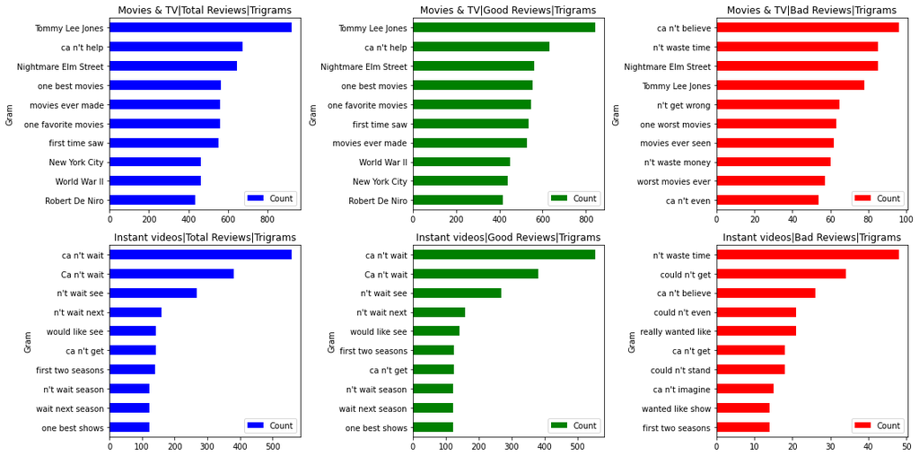

```python
%matplotlib inline
fig, ax = plt.subplots(2,3, figsize=(16,8))
summaryPlotGram(movies_tv['clean_words'], 3, 10, 'blue', ax[0][0])                                      # Total reviews, 10 frec trigrams (Movies&TV) -
summaryPlotGram(instant_video['clean_words'], 3, 10, 'blue', ax[1][0])                                  # Total reviews, 10 frec trigrams (Instant video) -
summaryPlotGram(movies_tv[movies_tv['overall'] >=3]['clean_words'], 3, 10, 'green', ax[0][1])           # Good reviews, 10 frec trigrams (Movies&TV) -
summaryPlotGram(instant_video[instant_video['overall'] >=3]['clean_words'], 3, 10, 'green', ax[1][1])   # Good reviews, 10 frec trigrams (Instant video) -
summaryPlotGram(movies_tv[movies_tv['overall'] <3]['clean_words'], 3, 10, 'red', ax[0][2])              # Bad reviews, 10 frec trigrams (Movies&TV) -
summaryPlotGram(instant_video[instant_video['overall'] <3]['clean_words'], 3, 10, 'red', ax[1][2])      # Bad reviews, 10 frec trigrams (Instant video) -
ax[0][0].set(title = 'Movies & TV|Total Reviews|Trigrams')
ax[1][0].set(title = 'Instant videos|Total Reviews|Trigrams')
ax[0][1].set(title = 'Movies & TV|Good Reviews|Trigrams')
ax[1][1].set(title = 'Instant videos|Good Reviews|Trigrams')
ax[0][2].set(title = 'Movies & TV|Bad Reviews|Trigrams')
ax[1][2].set(title = 'Instant videos|Bad Reviews|Trigrams')
fig.set_tight_layout(True)
```

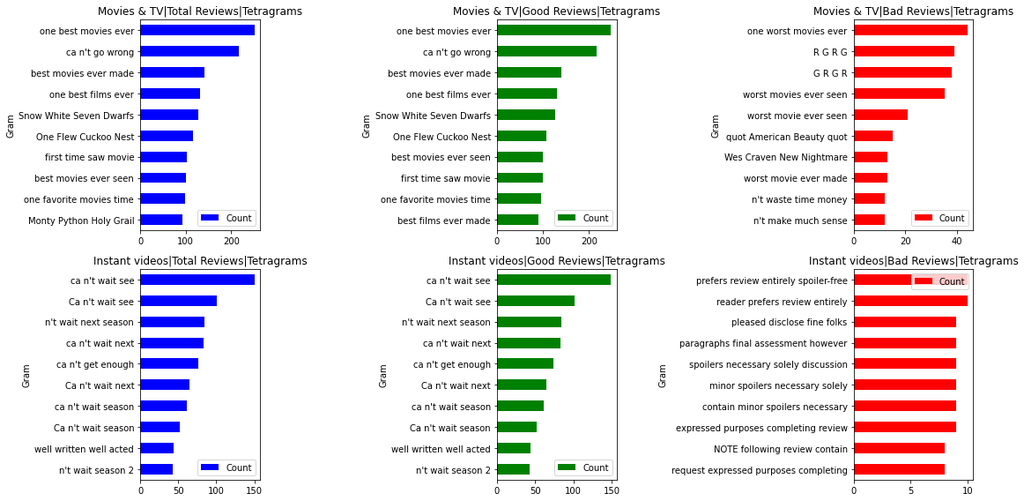

```python
%matplotlib inline
fig, ax = plt.subplots(2,3, figsize=(16,8))
summaryPlotGram(movies_tv['clean_words'], 4, 10, 'blue', ax[0][0])                                      # Total reviews, 10 frec tetragrams (Movies&TV) -
summaryPlotGram(instant_video['clean_words'], 4, 10, 'blue', ax[1][0])                                  # Total reviews, 10 frec tetragrams (Instant video) -
summaryPlotGram(movies_tv[movies_tv['overall'] >=3]['clean_words'], 4, 10, 'green', ax[0][1])           # Good reviews, 10 frec tetragrams (Movies&TV) -
summaryPlotGram(instant_video[instant_video['overall'] >=3]['clean_words'], 4, 10, 'green', ax[1][1])   # Good reviews, 10 frec tetragrams (Instant video) -
summaryPlotGram(movies_tv[movies_tv['overall'] <3]['clean_words'], 4, 10, 'red', ax[0][2])              # Bad reviews, 10 frec tetragrams (Movies&TV) -
summaryPlotGram(instant_video[instant_video['overall'] <3]['clean_words'], 4, 10, 'red', ax[1][2])      # Bad reviews, 10 frec tetragrams (Instant video) -
ax[0][0].set(title = 'Movies & TV|Total Reviews|Tetragrams')
ax[1][0].set(title = 'Instant videos|Total Reviews|Tetragrams')
ax[0][1].set(title = 'Movies & TV|Good Reviews|Tetragrams')
ax[1][1].set(title = 'Instant videos|Good Reviews|Tetragrams')
ax[0][2].set(title = 'Movies & TV|Bad Reviews|Tetragrams')
ax[1][2].set(title = 'Instant videos|Bad Reviews|Tetragrams')
fig.set_tight_layout(True)
```

It is observed that the bigramas show only some expressions that differ between good and bad reviews. For example, you have "great movie", "good movie", "story line" in good reviews but not in bad ones, on the other hand the expression "waste time" is striking on bad review.

It is noted that the score of the review is based more than anything on the quality or preferences of the user for the film than for the provision of the streaming service. So selecting a good movie catalog can greatly improve customer loyalty and retention.

### Exercise 6:

Throughout the above search for informative words, we have seen that unigrams are not enough, but important words (such as "good") are not always next to the informative words that they describe. Devise a method to extract these informative words. Provide a brief description of how you will extract the informative words.

**Answer.**

The informative words for this case are adjectives since they provide a qualification of the objects, these words usually refer to nouns, but as they are mentioned they are not always close to the noun to which they are named. We must use a strategy that allows us to find the closest nouns to your adjective. A tagging strategy can be used with a vector search, an example of the process is provided in the `extractAdjectiveNounPair()` function.

### Exercise 7:

Write a function(s) that transforms a sentence into a new text list by iteratively pairing each adjective in the sentence with the next noun that follows it in the sentence. For example, the text "That was a good, long movie" should return `["good movie", "long movie"]`.

**Answer.**

```python
def extractAdjectiveNounPair(data):
  # Data is a list with words
  # Perform tagging of each words, then select pairs (key and value) that are Nouns or Adjectives
  d = [(key,val) for key,val in nltk.pos_tag(data) if val in ['NN', 'NNS', 'NNP', 'NNPS', 'JJ', 'JJR', 'JJS']]
  # Select only adjective values from d - these are the first thing we are going to look for
  dA = [(key,val) for key,val in d if val in ['JJ', 'JJR', 'JJS']]
  # Return a vector of positions of the adjectives from 'd' (tagged words)
  pos = [[key for (key, val) in d].index(i) for (i,j) in dA]
  #
  pairs = []                                # Create an empty list
  #
  for i,(key, val) in enumerate(dA):
    # This select the tuple that contains the adjective
    adjective = d[pos[i]][0]
    # This list contains all words as tuple list till the position and then filter only nouns (result a list of nouns)
    # Select the last one
    try:
      list1 = [i for i,j in d[pos[i]:] if j in ['NN', 'NNS', 'NNP', 'NNPS']][0]
    except:
      list1 = '-' # In cases were there is an adjectives without posterior nouns
    #
    p = adjective + " " + list1           # Concatenation of adjective and noun
    pairs.append(p)                         # Extension of list

  return pairs

# d1 = movies_tv['clean_words'][1]
# print(d1)
# print(extractAdjectiveNounPair(d1))
```

```python
instant_video['pairAdjNoun'] = instant_video['clean_words'].map(lambda x: extractAdjectiveNounPair(x))
movies_tv['pairAdjNoun'] = movies_tv['clean_words'].map(lambda x: extractAdjectiveNounPair(x))
```

```python
def summaryPlotQualifier(data, k, color, ax):
  du = Counter([i for j in data for i in j]).most_common(k)
  df = pd.DataFrame({'Qualifier': dict(du).keys(), 'Count':map(int, dict(du).values())})
  df = df.sort_values('Count')
  plot = df.plot.barh(x='Qualifier', y='Count', color=color, ax=ax)
  return plot
```

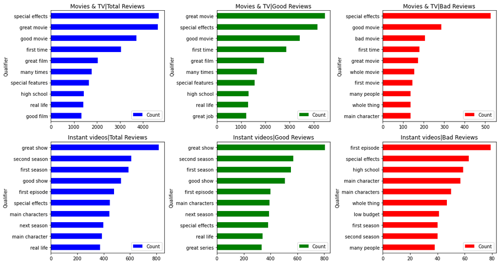

```python
%matplotlib inline
# A graph of most common pairs adjective + noun
fig, ax = plt.subplots(2,3, figsize=(15,8))
summaryPlotQualifier(movies_tv['pairAdjNoun'], 10, 'blue', ax[0][0])                                      # Total reviews, 10 frec tetragrams (Movies&TV) -
summaryPlotQualifier(instant_video['pairAdjNoun'], 10, 'blue', ax[1][0])                                  # Total reviews, 10 frec tetragrams (Instant video) -
summaryPlotQualifier(movies_tv[movies_tv['overall'] >=3]['pairAdjNoun'], 10, 'green', ax[0][1])           # Good reviews, 10 frec tetragrams (Movies&TV) -
summaryPlotQualifier(instant_video[instant_video['overall'] >=3]['pairAdjNoun'], 10, 'green', ax[1][1])   # Good reviews, 10 frec tetragrams (Instant video) -
summaryPlotQualifier(movies_tv[movies_tv['overall'] <3]['pairAdjNoun'], 10, 'red', ax[0][2])              # Bad reviews, 10 frec tetragrams (Movies&TV) -
summaryPlotQualifier(instant_video[instant_video['overall'] <3]['pairAdjNoun'], 10, 'red', ax[1][2])      # Bad reviews, 10 frec tetragrams (Instant video) -
ax[0][0].set(title = 'Movies & TV|Total Reviews')
ax[1][0].set(title = 'Instant videos|Total Reviews')
ax[0][1].set(title = 'Movies & TV|Good Reviews')
ax[1][1].set(title = 'Instant videos|Good Reviews')
ax[0][2].set(title = 'Movies & TV|Bad Reviews')
ax[1][2].set(title = 'Instant videos|Bad Reviews')
fig.set_tight_layout(True)
```